# Survival Analysis - multi-species random effects

This analysis is following the methods from [Muñoz et al. 2018](http://www.bioone.org/doi/full/10.1642/AUK-17-91.1). In each model, species is included as a random effect and we can therefore extract mean information about the community. Due to the way the estimation works, we can also extract the survival estimates for individual species.

## Data

We are estimating apparent survival for 28 species. The recaptures have been grouped by year, so we have 11 recapture periods (from 33, 3 per year) in order to get annual survival estimates.

## Full model analysis

In the full model, we use a TSM approach (estimate survival between banding and first recapture separately from all other recaptures) to estimate mean apparent survival for each habitat type. We also extract the mean species level estimates, and the mean specialism group level estimates. We estimate p separately for each habitat to control for dectability differences in the three habitats.

```r
mod_out <- jags(data = mod_data, model.file = "code/multi_sp_survival.bug.R", inits = inits,
                n.iter = 20000, n.chains = 3, parameters.to.save = params)
save(mod_out, file="results/multi_sp_model.rda")
```

```r
load("results/multi_sp_model.rda")
sims <- mod_out$BUGSoutput$sims.array
# keep param names to reattach
params <- names(sims[1,1,])
# convert to 2d array
dim(sims) <- c(prod(dim(sims)[1:2]), dim(sims)[3])
colnames(sims) <- params

sims_narrow <- as.tibble(sims) %>%
  gather(key = param, value = value) %>%
  mutate(param = str_replace(param, "\\[", "_"),
         param = str_replace(param, "\\]", "")) %>%
  separate(param, into = c("param_name", "param_index"), sep = "_")
summ <- as_tibble(mod_out$BUGSoutput$summary, rownames = "param") %>%
  mutate(param = str_replace(param, "\\[", "_"),
         param = str_replace(param, "\\]", "")) %>%
  separate(param, into = c("param_name", "param_index"), sep = "_")
```

### Posterior distributions of survival estimates in each habitat type

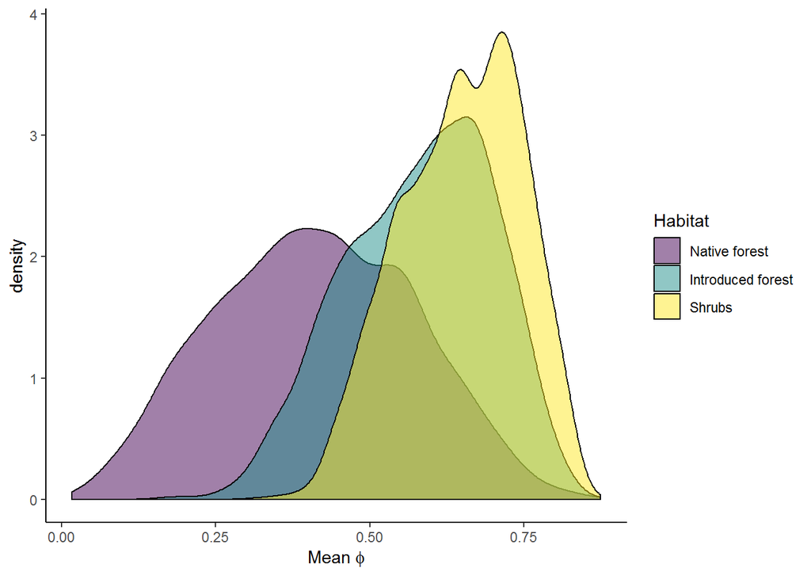

```r
hab_comp <- filter(sims_narrow, param_name == "mean.phi") %>%
  separate(param_index, into = c("a", "h")) %>%
  filter(a == 2) %>%
  mutate(Habitat = factor(h, levels=c(2, 1, 3),
                          labels=c("Native forest", "Introduced forest", "Shrubs"))) %>%
  select(Habitat, value)

ggplot(hab_comp, aes(x=value, fill=Habitat)) +
  geom_density(alpha=0.5, position="identity") +
  scale_fill_viridis_d() +
  xlab(expression("Mean "*phi))
```

### Posterior distributions of detection probability in each habitat type

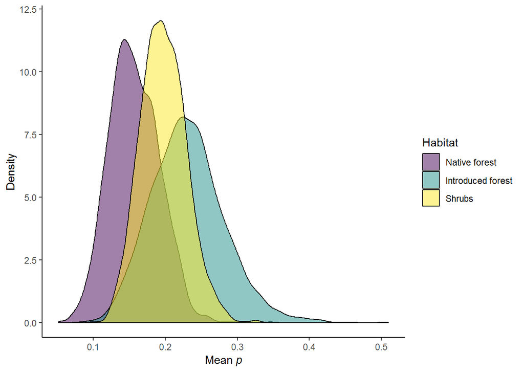

```r
hab_p <- filter(sims_narrow, param_name == "mean.p") %>%
  mutate(Habitat = factor(param_index, levels=c(2, 1, 3),
                          labels=c("Native forest", "Introduced forest", "Shrubs"))) %>%
  select(Habitat, value)

hab_p_plot <- ggplot(hab_p, aes(x=value, fill=Habitat)) +
  geom_density(alpha=0.5, position="identity") +
  scale_fill_viridis_d() +
  xlab(expression("Mean "*italic("p"))) + ylab("Density")

hab_p_plot
```

```r
save_plot("doc/figureS1_habitat_detection_comparison.png", plot = hab_p_plot)
```

Any difference there is between habitats is likely down to the lower detection probability.

### Posterior distributions of the difference between survival estimates in each habitat type

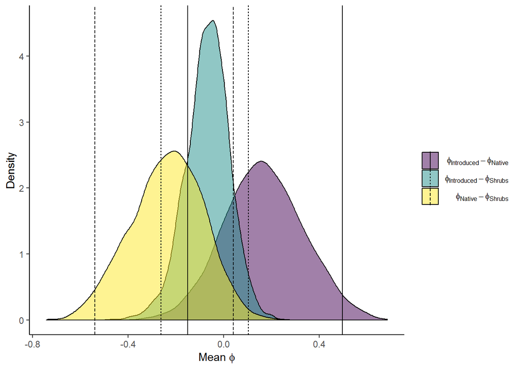

```r
hab_comp <- filter(sims_narrow, param_name %in% c("indiff", "isdiff", "nsdiff")) %>%
  select(param_name, value)

hab_summary <- filter(summ, param_name %in% c("indiff", "isdiff", "nsdiff")) %>%
  select(param_name, LCI = `2.5%`, UCI = `97.5%`) %>% gather(CI, value, -param_name)

hab_comp_plot <- ggplot(hab_comp, aes(x=value, fill=param_name)) +
  geom_density(alpha=0.5, position="identity") +
  scale_fill_viridis_d(name = "", labels = c(expression(phi[Introduced] - phi[Native]),
                                  expression(phi[Introduced] - phi[Shrubs]),
                                  expression(phi[Native] - phi[Shrubs]))) +
  geom_vline(data = hab_summary, aes(xintercept = value, linetype = param_name)) +
  scale_linetype_discrete(name = "", labels = c(expression(phi[Introduced] - phi[Native]),
                                  expression(phi[Introduced] - phi[Shrubs]),
                                  expression(phi[Native] - phi[Shrubs]))) +
  xlab(expression("Mean "*phi)) + ylab("Density")

hab_comp_plot
```

```r
save_plot("doc/figure1_habitat_comparison.png", plot = hab_comp_plot)
```

Note that all 95% CIs of the differences between habitats include zero, so we cannot draw any conclusions about the difference in survival estimate between habitat types.

### Posterior summaries of group differences in apparent survival

```r
group_comp <- filter(sims_narrow, param_name == "speciesphi2") %>%
  mutate(species_no = param_index %>% as.numeric) %>%
    inner_join(arrange(species_info, species) %>%
               mutate(species_no = species %>% as.factor %>% as.numeric)) %>%
   mutate(specialization = factor(specialization,
                                  labels=sp_labels))
```

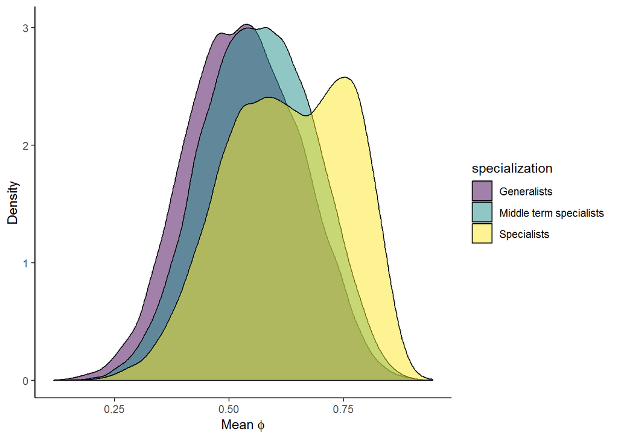

```r
sp_comp_plot <- ggplot(group_comp, aes(x=value, fill=specialization)) +
  geom_density(alpha=0.5, position="identity") +
  scale_fill_viridis_d() +
  xlab(expression("Mean "*phi)) + ylab("Density")

sp_comp_plot
```

```r
save_plot("doc/figure2_specialism_comparison.png", plot = sp_comp_plot)

beta_group <- filter(summ, param_name == "beta.group") %>% mutate(value = paste0(round(mean, 2), " (", round(`2.5%`, 2), ", ", round(`97.5%`, 2), ")")) %>% pull(value)
```

When we include the group identity as a covariate on phi, while also controlling for phylogenetic correlation by including family as a random factor (following the Muñoz paper), we get a non-important group effect of 0.15 (-0.12, 0.41).

### Apparent survival estimates for each species

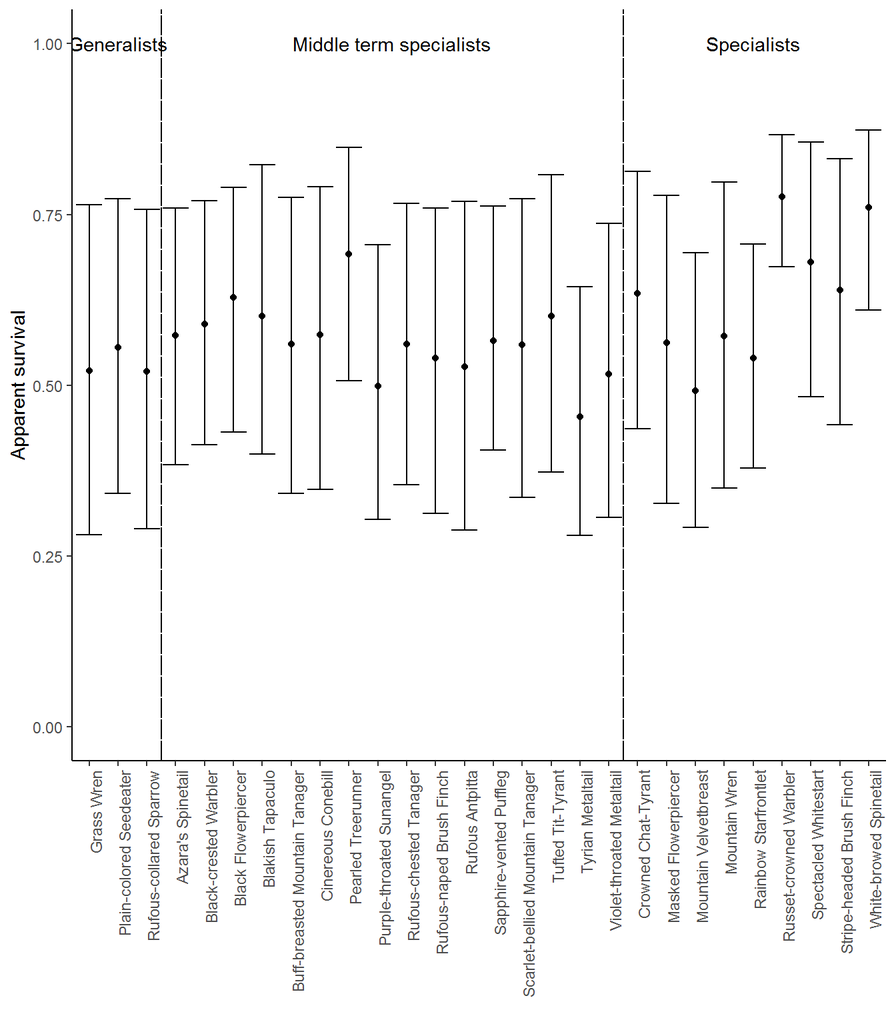

```r
survival_comp <- filter(summ, param_name == "speciesphi2") %>%
  bind_cols(arrange(species_info, species)) %>%
  select(species = common, specialization, mean_val = mean, LCI = `2.5%`, UCI = `97.5%`) %>%
  arrange(specialization, species) %>%
  mutate(species = factor(species, levels = species))

# get the species names in the right order
sp_names <- distinct(survival_comp, species, specialization) %>%
  arrange(specialization, species)

sp_names$specialization <- factor(sp_names$specialization, labels=sp_labels)


# need to know where lines between specializations are
sp_last <- group_by(sp_names, specialization) %>%
  filter(row_number()==n())

sp_last_position <- which(sp_names$species %in% sp_last$species)

sp_first <- group_by(sp_names, specialization) %>%
  filter(row_number()==1)

sp_first_position <- which(sp_names$species %in% sp_first$species)

sp_text_position <- (sp_last_position - sp_first_position)/2 + sp_first_position

specializations <- levels(sp_names$specialization)

pd <- position_dodge(1)

ggplot(survival_comp, aes(x = species, y = mean_val)) +
  geom_point() +
  geom_errorbar(aes(ymin = LCI, ymax = UCI)) +
  geom_vline(xintercept = sp_last_position[1:length(sp_last_position)-1] + 0.5, linetype = "F1") +
  annotate("text", x = sp_text_position, y = 1, label = specializations) +
  scale_y_continuous(limits = c(0, 1)) +
  labs(x = "", y = "Apparent survival") +
  theme(axis.text.x = element_text(angle = 90, hjust = 1))
```

```r
write_csv(survival_comp, "results/multi_sp_survival.csv")
```

### Detection probability estimates for each species

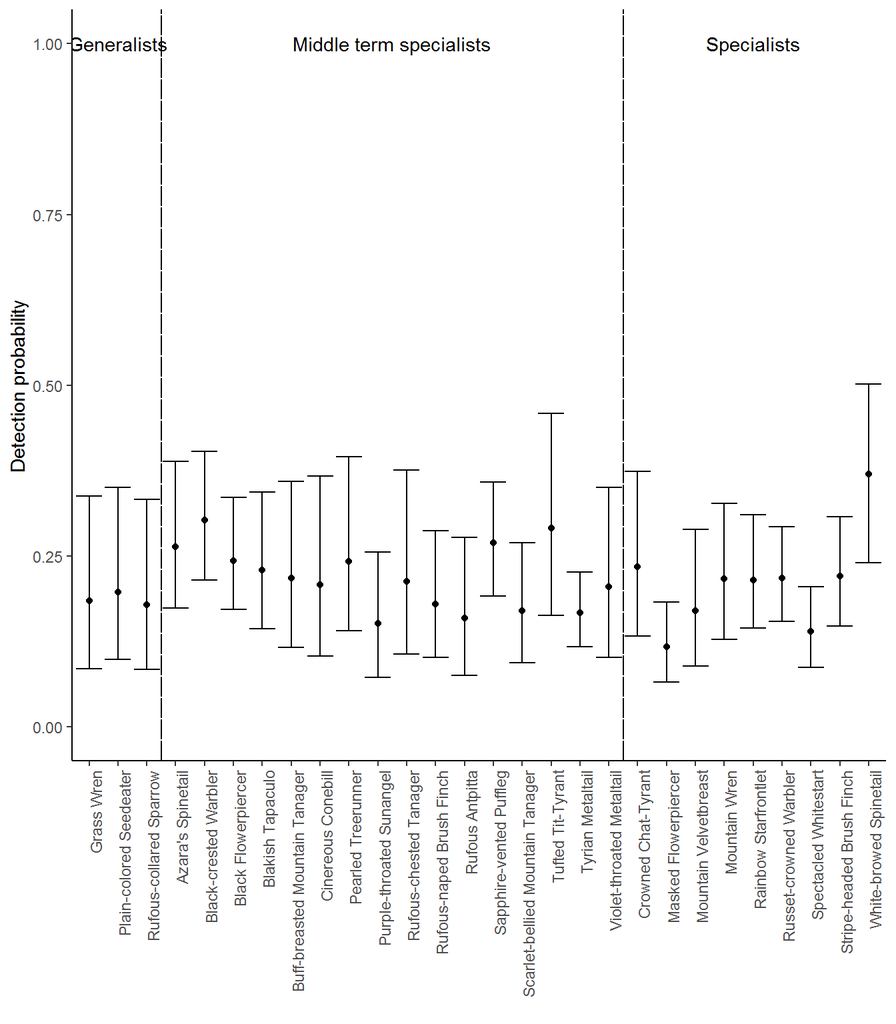

```r
detection_comp <- filter(summ, param_name == "speciesp") %>%
  bind_cols(arrange(species_info, species)) %>%
  select(species = common, specialization, mean_val = mean, LCI = `2.5%`, UCI = `97.5%`) %>%
  arrange(specialization, species) %>%
  mutate(species = factor(species, levels = species))

pd <- position_dodge(1)

ggplot(detection_comp, aes(x = species, y = mean_val)) +
  geom_point() +
  geom_errorbar(aes(ymin = LCI, ymax = UCI)) +
  geom_vline(xintercept = sp_last_position[1:length(sp_last_position)-1] + 0.5, linetype = "F1") +
  annotate("text", x = sp_text_position, y = 1, label = specializations) +
  scale_y_continuous(limits = c(0, 1)) +
  labs(x = "", y = "Detection probability") +
  theme(axis.text.x = element_text(angle = 90, hjust = 1))
```

```r
write_csv(detection_comp, "results/multi_sp_detection.csv")
```

### Variation in apparent survival between habitats for each species

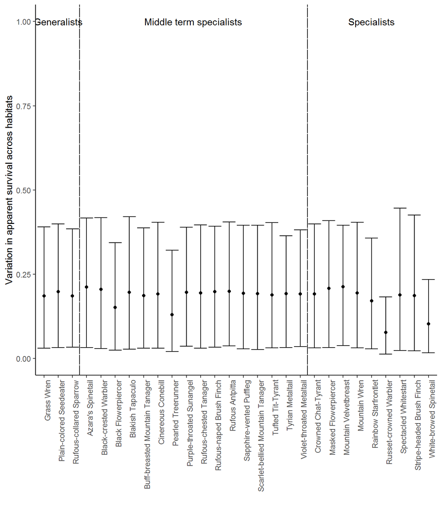

```r
habvar_comp <- filter(summ, param_name == "speciesphi2sd") %>%
  bind_cols(arrange(species_info, species)) %>%
  select(species = common, specialization, mean_val = mean, LCI = `2.5%`, UCI = `97.5%`) %>%
  arrange(specialization, species) %>%
  arrange(specialization, species) %>%
  mutate(species = factor(species, levels = species))

# get the species names in the right order
sp_names <- distinct(habvar_comp, species, specialization) %>%
  arrange(specialization, species)

sp_names$specialization <- factor(sp_names$specialization, labels=sp_labels)


# need to know where lines between specializations are
sp_last <- group_by(sp_names, specialization) %>%
  filter(row_number()==n())

sp_last_position <- which(sp_names$species %in% sp_last$species)

sp_first <- group_by(sp_names, specialization) %>%
  filter(row_number()==1)

sp_first_position <- which(sp_names$species %in% sp_first$species)

sp_text_position <- (sp_last_position - sp_first_position)/2 + sp_first_position

specializations <- levels(sp_names$specialization)

pd <- position_dodge(1)

ggplot(habvar_comp, aes(x = species, y = mean_val)) +
  geom_point() +
  geom_errorbar(aes(ymin = LCI, ymax = UCI)) +
  geom_vline(xintercept = sp_last_position[1:length(sp_last_position)-1] + 0.5, linetype = "F1") +
  annotate("text", x = sp_text_position, y = 1, label = specializations) +
  scale_y_continuous(limits = c(0, 1)) +
  labs(x = "", y = "Variation in apparent survival across habitats") +
  theme(axis.text.x = element_text(angle = 90, hjust = 1))
```

```r
write_csv(habvar_comp, "results/multi_sp_habvar.csv")
```

### Apparent survival estimates for each species by habitat

```r
survival_hab_comp <- filter(summ, param_name == "phi") %>%
  separate(param_index, into=c("species", "tsm", "habitat")) %>%
  filter(tsm == 2) %>%
  mutate(species_no = species %>% as.integer,
         habitat = factor(habitat, levels=c(2,1,3), labels=c("Native forest", "Introduced forest", "Shrubs"))) %>%
  select(-species) %>%
  inner_join(arrange(species_info, species) %>%
               mutate(species_no = species %>% as.factor %>% as.numeric)) %>%
  select(species = common, specialization, habitat, mean_val = mean, LCI = `2.5%`, UCI = `97.5%`) %>%
  arrange(specialization, species) %>%
  mutate(species = factor(species, levels = habvar_comp$species))
```

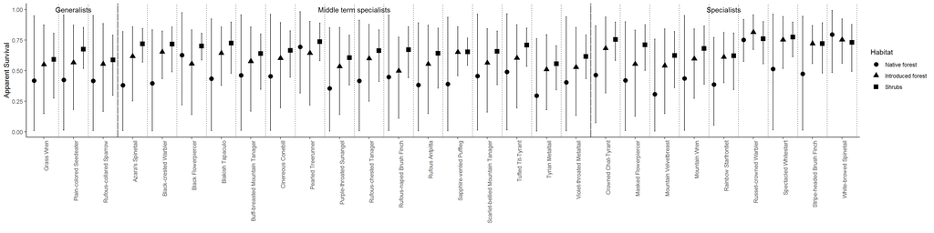

```r
pd <- position_dodge(1)

survival_hab_plot <- ggplot(survival_hab_comp, aes(x = species, y = mean_val, group=habitat)) +
  geom_errorbar(aes(ymin=LCI, ymax=UCI), colour="black", width=.1, position=pd) +
  geom_point(position=pd, aes(shape=habitat), size=3) +
  geom_vline(xintercept = 1:nrow(sp_names) + 0.5, linetype = "dotted") +
  geom_vline(xintercept = sp_last_position[1:length(sp_last_position)-1] + 0.5, linetype = "F1") +
  annotate("text", x = sp_text_position, y = 1, label = specializations) +
  labs(x = "", y = "Apparent Survival", shape = "Habitat") +
  theme(axis.text.x = element_text(angle = 90, hjust = 1))

save_plot("doc/figureS2_survival_hab_plot.png", survival_hab_plot, base_width = 20, base_height = 10)

write_csv(survival_hab_comp, "results/multi_sp_survival_hab.csv")

survival_hab_plot
```

```r
table1 <- filter(summ, param_name %in% c("speciesphi1", "speciesphi2", "speciesp")) %>%
  mutate(value = paste0(round(mean, 2), " (", round(`2.5%`, 2), ", ", round(`97.5%`, 2), ")")) %>%
  select(param_name, param_index, value) %>%
  mutate(param_index = param_index %>% as.integer) %>%
  spread(param_name, value) %>%
  bind_cols(arrange(species_info, species)) %>%
  mutate(specialization = factor(specialization,
                                 labels=sp_labels)) %>%
  arrange(specialization, common) %>%
  select(species = common, specialization, p = speciesp, phi1 = speciesphi1, phi2 = speciesphi2)

write_csv(table1, "doc/table1_survival_estimates.csv")

kable(table1)
```

| species | specialization | p | phi1 | phi2 |
| --- | --- | --- | --- | --- |
| Grass Wren | Generalists | 0.18 (0.09, 0.34) | 0.46 (0.3, 0.63) | 0.52 (0.28, 0.76) |
| Plain-colored Seedeater | Generalists | 0.2 (0.1, 0.35) | 0.46 (0.32, 0.59) | 0.56 (0.34, 0.77) |
| Rufous-collared Sparrow | Generalists | 0.18 (0.08, 0.33) | 0.48 (0.33, 0.64) | 0.52 (0.29, 0.76) |
| Azara’s Spinetail | Middle term specialists | 0.26 (0.17, 0.39) | 0.58 (0.46, 0.69) | 0.57 (0.38, 0.76) |
| Black-crested Warbler | Middle term specialists | 0.3 (0.21, 0.4) | 0.63 (0.53, 0.73) | 0.59 (0.41, 0.77) |
| Black Flowerpiercer | Middle term specialists | 0.24 (0.17, 0.34) | 0.49 (0.39, 0.59) | 0.63 (0.43, 0.79) |
| Blakish Tapaculo | Middle term specialists | 0.23 (0.14, 0.34) | 0.63 (0.51, 0.77) | 0.6 (0.4, 0.82) |
| Buff-breasted Mountain Tanager | Middle term specialists | 0.22 (0.12, 0.36) | 0.52 (0.39, 0.65) | 0.56 (0.34, 0.77) |
| Cinereous Conebill | Middle term specialists | 0.21 (0.1, 0.37) | 0.54 (0.41, 0.67) | 0.57 (0.35, 0.79) |
| Pearled Treerunner | Middle term specialists | 0.24 (0.14, 0.4) | 0.55 (0.42, 0.68) | 0.69 (0.51, 0.85) |
| Purple-throated Sunangel | Middle term specialists | 0.15 (0.07, 0.26) | 0.4 (0.27, 0.52) | 0.5 (0.3, 0.71) |
| Rufous-chested Tanager | Middle term specialists | 0.21 (0.11, 0.38) | 0.53 (0.4, 0.65) | 0.56 (0.35, 0.77) |
| Rufous-naped Brush Finch | Middle term specialists | 0.18 (0.1, 0.29) | 0.5 (0.37, 0.63) | 0.54 (0.31, 0.76) |
| Rufous Antpitta | Middle term specialists | 0.16 (0.08, 0.28) | 0.47 (0.29, 0.64) | 0.53 (0.29, 0.77) |
| Sapphire-vented Puffleg | Middle term specialists | 0.27 (0.19, 0.36) | 0.43 (0.32, 0.51) | 0.57 (0.41, 0.76) |
| Scarlet-bellied Mountain Tanager | Middle term specialists | 0.17 (0.09, 0.27) | 0.59 (0.46, 0.7) | 0.56 (0.34, 0.77) |
| Tufted Tit-Tyrant | Middle term specialists | 0.29 (0.16, 0.46) | 0.58 (0.44, 0.72) | 0.6 (0.37, 0.81) |
| Tyrian Metaltail | Middle term specialists | 0.17 (0.12, 0.23) | 0.47 (0.39, 0.55) | 0.45 (0.28, 0.64) |
| Violet-throated Metaltail | Middle term specialists | 0.2 (0.1, 0.35) | 0.42 (0.3, 0.54) | 0.52 (0.31, 0.74) |
| Crowned Chat-Tyrant | Specialists | 0.23 (0.13, 0.37) | 0.57 (0.43, 0.71) | 0.63 (0.44, 0.81) |
| Masked Flowerpiercer | Specialists | 0.12 (0.07, 0.18) | 0.55 (0.43, 0.66) | 0.56 (0.33, 0.78) |
| Mountain Velvetbreast | Specialists | 0.17 (0.09, 0.29) | 0.47 (0.35, 0.58) | 0.49 (0.29, 0.69) |
| Mountain Wren | Specialists | 0.22 (0.13, 0.33) | 0.57 (0.42, 0.71) | 0.57 (0.35, 0.8) |
| Rainbow Starfrontlet | Specialists | 0.21 (0.14, 0.31) | 0.47 (0.37, 0.57) | 0.54 (0.38, 0.71) |
| Russet-crowned Warbler | Specialists | 0.22 (0.15, 0.29) | 0.63 (0.53, 0.72) | 0.78 (0.67, 0.87) |
| Spectacled Whitestart | Specialists | 0.14 (0.09, 0.21) | 0.65 (0.54, 0.74) | 0.68 (0.48, 0.86) |
| Stripe-headed Brush Finch | Specialists | 0.22 (0.15, 0.31) | 0.61 (0.48, 0.73) | 0.64 (0.44, 0.83) |
| White-browed Spinetail | Specialists | 0.37 (0.24, 0.5) | 0.61 (0.48, 0.73) | 0.76 (0.61, 0.87) |

```r
detect_hab_comp <- filter(summ, param_name == "p") %>%
  separate(param_index, into=c("species", "habitat")) %>%
  mutate(species_no = species %>% as.integer,
         habitat = factor(habitat, levels=c(2,1,3), labels=c("Native forest", "Introduced forest", "Shrubs"))) %>%
  select(-species) %>%
  inner_join(arrange(species_info, species) %>%
               mutate(species_no = species %>% as.factor %>% as.numeric)) %>%
  select(species = common, specialization, habitat, mean_val = mean, LCI = `2.5%`, UCI = `97.5%`) %>%
  arrange(specialization, species) %>%
  mutate(species = factor(species, levels = habvar_comp$species))
table_s2 <- filter(summ, param_name %in% c("phi", "p")) %>%
  mutate(value = paste0(round(mean, 2), " (", round(`2.5%`, 2), ", ", round(`97.5%`, 2), ")")) %>%
  separate(param_index, into=c("species", "tsm", "habitat")) %>%
  filter(tsm == 2) %>%
  mutate(species_no = species %>% as.integer,
         habitat = factor(habitat, levels=c(2,1,3), labels=c("Native forest", "Introduced forest", "Shrubs"))) %>%
  select(-species) %>%
  inner_join(arrange(species_info, species) %>%
               mutate(species_no = species %>% as.factor %>% as.numeric)) %>%
  select(species = common, specialization, habitat, value, param_name) %>%
  spread(param_name, value) %>% mutate(specialization = factor(specialization,
                                 labels=sp_labels)) %>%
  arrange(specialization, species)
table_s2 <- bind_rows(survival_hab_comp %>% mutate(param = "phi"),
                      detect_hab_comp %>% mutate(param = "p")) %>%
  mutate(value = paste0(round(mean_val, 2), " (", round(LCI, 2), ", ", round(UCI, 2), ")")) %>%
  select(species, specialization, habitat, param, value) %>%
  spread(param, value) %>%
  mutate(specialization = factor(specialization,
                                 labels=sp_labels)) %>%
  arrange(specialization, species)

write_csv(table_s2, "doc/tableS2_habitat_survival_estimates.csv")

kable(table_s2)
```

| species | specialization | habitat | p | phi |
| --- | --- | --- | --- | --- |
| Grass Wren | Generalists | Native forest | 0.17 (0.04, 0.38) | 0.42 (0.01, 0.95) |
| Grass Wren | Generalists | Introduced forest | 0.25 (0.03, 0.67) | 0.55 (0.15, 0.87) |
| Grass Wren | Generalists | Shrubs | 0.14 (0.05, 0.29) | 0.59 (0.28, 0.81) |
| Plain-colored Seedeater | Generalists | Native forest | 0.17 (0.04, 0.4) | 0.43 (0.01, 0.95) |
| Plain-colored Seedeater | Generalists | Introduced forest | 0.23 (0.03, 0.64) | 0.57 (0.18, 0.87) |
| Plain-colored Seedeater | Generalists | Shrubs | 0.19 (0.09, 0.34) | 0.68 (0.52, 0.85) |
| Rufous-collared Sparrow | Generalists | Native forest | 0.17 (0.04, 0.39) | 0.42 (0.01, 0.95) |
| Rufous-collared Sparrow | Generalists | Introduced forest | 0.22 (0.02, 0.61) | 0.56 (0.17, 0.88) |
| Rufous-collared Sparrow | Generalists | Shrubs | 0.15 (0.07, 0.27) | 0.59 (0.3, 0.79) |
| Azara’s Spinetail | Middle term specialists | Native forest | 0.19 (0.07, 0.4) | 0.38 (0.01, 0.82) |
| Azara’s Spinetail | Middle term specialists | Introduced forest | 0.26 (0.09, 0.55) | 0.62 (0.25, 0.86) |
| Azara’s Spinetail | Middle term specialists | Shrubs | 0.34 (0.23, 0.47) | 0.72 (0.57, 0.85) |
| Black-crested Warbler | Middle term specialists | Native forest | 0.17 (0.08, 0.3) | 0.4 (0.01, 0.83) |
| Black-crested Warbler | Middle term specialists | Introduced forest | 0.46 (0.26, 0.68) | 0.65 (0.44, 0.82) |
| Black-crested Warbler | Middle term specialists | Shrubs | 0.28 (0.16, 0.45) | 0.72 (0.49, 0.86) |
| Black Flowerpiercer | Middle term specialists | Native forest | 0.2 (0.07, 0.42) | 0.63 (0.22, 0.98) |
| Black Flowerpiercer | Middle term specialists | Introduced forest | 0.14 (0.04, 0.31) | 0.56 (0.14, 0.83) |
| Black Flowerpiercer | Middle term specialists | Shrubs | 0.4 (0.28, 0.53) | 0.7 (0.59, 0.81) |
| Blakish Tapaculo | Middle term specialists | Native forest | 0.19 (0.07, 0.37) | 0.44 (0.01, 0.92) |
| Blakish Tapaculo | Middle term specialists | Introduced forest | 0.27 (0.14, 0.43) | 0.64 (0.38, 0.86) |
| Blakish Tapaculo | Middle term specialists | Shrubs | 0.23 (0.08, 0.5) | 0.73 (0.48, 0.9) |
| Buff-breasted Mountain Tanager | Middle term specialists | Native forest | 0.17 (0.04, 0.38) | 0.46 (0.01, 0.96) |
| Buff-breasted Mountain Tanager | Middle term specialists | Introduced forest | 0.18 (0.03, 0.45) | 0.58 (0.17, 0.86) |
| Buff-breasted Mountain Tanager | Middle term specialists | Shrubs | 0.31 (0.12, 0.6) | 0.64 (0.35, 0.8) |
| Cinereous Conebill | Middle term specialists | Native forest | 0.17 (0.04, 0.37) | 0.45 (0.01, 0.96) |
| Cinereous Conebill | Middle term specialists | Introduced forest | 0.24 (0.03, 0.69) | 0.6 (0.2, 0.89) |
| Cinereous Conebill | Middle term specialists | Shrubs | 0.21 (0.09, 0.38) | 0.67 (0.45, 0.83) |
| Pearled Treerunner | Middle term specialists | Native forest | 0.18 (0.09, 0.31) | 0.69 (0.32, 0.98) |
| Pearled Treerunner | Middle term specialists | Introduced forest | 0.2 (0.02, 0.59) | 0.64 (0.22, 0.9) |
| Pearled Treerunner | Middle term specialists | Shrubs | 0.34 (0.17, 0.58) | 0.74 (0.58, 0.89) |

[output cut: 54 more lines]